# LeerAccess Oplossingen

Auteur

Ben Welman

Publicatiedatum

16 februari 2023

# 1 Intro

Oplossingen voor de opgaven in het studieboek [LeerAccess](https://leeraccess.netlify.app/).

# 2 Verkennen

**Oefening 2.1** **Selectie Bonbons (expl001)**

De selectie kan via filteren verkregen worden. Open de tabel Bonbons. Maak een filter in de kolom Chocoladetype en selecteer uitsluitend de waarden `Melk` en `Puur`. Klik in de kolom Bonbonkosten in een veld met de waarde `0,3`. Kies dan tab Start > Selectie (groep Sorteren en filteren) > Kleiner dan of gelijk aan € 0,30.

**Oefening 2.2** **Selectie Klanten op plaatsnaam (expl002)**

Open de tabel Klanten. Klik op de filterpijl aan het eind van de kolomkop Plaats en selecteer uitsluitend `Almelo`, `Enschede`, `Hengelo`.

**Oefening 2.3** **Selectie Klanten op postcode (expl003)**

Open de tabel Klanten. Klik in de kolom Plaats in een vak met de waarde `Amsterdam`. Kies dan tab Start > Selectie (groep Sorteren en filteren) > is gelijk aan Amsterdam. Klik op de filterpijl aan het eind van de kolomkop Postcode en kies Tekstfilters > Begint met …. Typ daarna in `20` en klik op OK.

# 3 Data

**Oefening 3.1** **Bonbons toevoegen (data001)**

Open het formulier Bonbons. Klik op de knop voor een nieuw record en voeg de bonbons toe.

**Oefening 3.2** **Order toevoegen (data002)**

Zoek eerst in de tabel Klanten de klantcode op van Rebecca Smit. Dit is `11`. Open daarna het formulier Orders. Ga naar de laatste order. Deze heeft ordercode `967`. De nieuwe order krijgt daarom ordercode `968`. Klik op de knop Nieuw Record. Voeg in ordercode `968`, de orderdatum en klantcode `11` in. Voeg onderaan in het subformulier de te bestellen dozen (KERS en MARS) in.

Om de dozen MARS te verwijderen open je de tabel Orderdetails, ga naar de laatste order met ordercode `968`. Selecteer de orderregel met Mars, rechter muisknop en dan Record verwijderen.

# 4 Tabellen

**Oefening 4.1** **Dubbele namen voorkomen (tabl001)**

Open de tabel Leveranciers in de Ontwerpweergave. Verander bij het veld Leverancier de eigenschap Geïndexeerd in Ja (Geen duplicaten).

**Oefening 4.2** **Tussenvoegsel in namen (tabl002)**

Er moet dan aan de tabel Klanten een nieuw veld Tussenvoegsel worden toegevoegd. In het veld Achternaam komt dan alleen `Molen` te staan. In het veld Tussenvoegsel komt `van de` te staan. Sorteren op Achternaam geeft dan de gewenste weergave. Op een etiket kan dan op één regel achter elkaar de velden Voornaam Tussenvoegsel en Achternaam worden gezet.

**Oefening 4.3** **Titelveld met keuzelijst (tabl003)**

Open de tabel Klanten in de ontwerpweergave. Voeg een veld Titel toe. Kies bij Gegevenstype voor Wizard opzoeken…. Geef bij het dan volgende dialoogscherm aan dat de waarden worden ingetypt. Er is maar 1 kolom nodig. Typ in deze kolom onder elkaar in: ing., ir., drs., mr., dr. Gebruik voor het bijschrift de tekst `Titel`.

**Oefening 4.4** **Valutanotatie (tabl004)**

Open de tabel Vervoer in de Ontwerpweergave, selecteer het veld Vervoerskosten en wijzig de waarde van de eigenschap Notatie in `Euro`.

**Oefening 4.5** **Samengestelde sleutel (tabl005)**

Open de tabel Vervoer in de Ontwerpweergave. Selecteer de velden ID vervoersbedrijf en Aflever-provincie. Klik daarna op de knop Primaire sleutel.

**Oefening 4.6** **Veld doelgroep met keuzelijst (tabl006)**

Open de tabel Klanten in de ontwerpweergave. Voeg een veld Doelgroep toe. Kies bij Gegevenstype voor Wizard opzoeken…. Geef bij het dan volgende dialoogscherm aan dat de waarden worden ingetypt. Er is maar 1 kolom nodig. Typ in deze kolom onder elkaar in: top klant, goede klant, kleine klant. Gebruik voor het bijschrift de tekst `Doelgroep`.

**Oefening 4.7** **Relatie maken (tabl007)**

De tabellen Doosdetails en Bonbons hebben het veld Bonboncode als gemeenschappelijk veld. Bonboncode is in de tabel Bonbons de sleutel; dus is Bonbons de primaire tabel (de één kant). Een bepaalde Bonboncode kan in de tabel Doosdetails vaker voorkomen, dus is Doosdetails de veel kant. Kies tab Hulpmiddelen voor databases > Relaties (groep Relaties). Selecteer het veld Bonboncode in de tabel Bonbons en sleep deze naar het veld Bonboncode in de tabel Doosdetails. Het vakje Referentiële integriteit afdwingen inschakelen.

**Oefening 4.8** **Tabel Werknemers (tabl008)**

Import van het Excelbestand.

1. Kies tab Externe gegevens > Nieuwe gegevensbron (groep importeren en koppelen) > Uit bestand > Excel.
2. Selecteer het bestand `Werknemers.xlsx` en kies voor De brongegevens importeren in een nieuwe tabel in de huidige database.
3. Selecteer de optie Eerste rij bevat kolomkoppen.
4. Wijzig het Gegevenstype van het veld Werknemercode van Dubbele precisie in Lange integer.
5. Maak het veld Werknemercode de primaire sleutel.
6. Geef de nieuwe tabel de naam Werknemers.

Uitbreiding van de tabel Orders.

1. Open de tabel Orders in de Ontwerpweergave.
2. Voeg een veld toe met de naam Werknemercode met als Gegevenstype Numeriek en als Veldlengte Lange integer.

Relatie tot stand brengen.

1. Kies tab Hulpmiddelen voor databases > Relaties (groep Relaties).
2. Kies tab Ontwerp > tabel weergeven (groep Relaties) en voeg de tabel Werknemers aan het raster toe.
3. Selecteer het veld Werknemercode in de tabel Werknemers en sleep deze naar het veld Werknemercode in de tabel Orders. Het vakje Referentiële integriteit afdwingen inschakelen.

**Oefening 4.9** **Contactregistratie (tabl009)**

Er moet eigenlijk eerst een informatie-analyse gemaakt worden. Het resultaat hiervan moet opleveren welke velden in de tabel Contacten moeten komen, wat de sleutel wordt en of er relaties met de andere tabellen moeten komen en zo ja via welke velden. Er kan dan ook niet één goed antwoord gegeven worden. Een mogelijk antwoord wordt in de afbeelding hierna weergegeven:

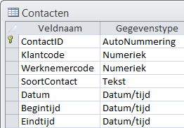

Aandachtspunten bij dit ontwerp en ook bij een ander ontwerp:

- Van een klant zullen meerdere contacten vastgelegd moeten kunnen worden. Vandaar een sleutelveld ContactID en de opname van het veld Klantcode (gegevenstype: Numeriek - Lange integer) waarmee een koppeling met de tabel Klanten gemaakt kan worden.
- Wanneer de tabel Werknemers beschikbaar is, dan is het wel zo handig om bij de registratie van een contactmoment ook op te kunnen nemen door welke werknemer het contact is afgehandeld. In dat geval kan het veld Werknemercode (gegevenstype: Numeriek - Lange integer) opgenomen worden waarmee een koppeling met de tabel Werknemers gelegd kan worden.
- Uit de informatie-analyse moet blijken welke waarden het veld SoortContact moet hebben. Voor dit veld kan dan het beste een opzoektabel gemaakt worden waarin de waarden zijn vastgelegd.
- Voor de drie Datum/tijd velden moet een geschikte notatie gekozen worden, eventueel met een invoermasker.
- Uit de informatie-analyse moet blijken hoe er met de berekening van de kosten wordt omgegaan. De afhandelingstijd kan berekend worden uit de begin- en eindtijd, is dus een procesgegeven en moet dus niet worden opgenomen in de tabel. Als het uurtarief een constante is, dan kan deze ook worden weggelaten uit de tabel. In dat geval wordt er dan niets over de kosten in de tabel opgenomen en wordt de berekening ervan uitgevoerd op het moment dat je dat wilt weten, bij een query of rapport. Varieert het uurtarief wel in de tijd, dan moet het uurtarief in de tabel worden opgenomen.

**Oefening 4.10** **Klachtenregistratie (tabl010)**

Voor het veld SoortKlacht kan het beste een opzoektabel gemaakt worden waarin de waarden zijn vastgelegd.

Er moet een relatie gelegd worden tussen deze tabel en de tabel Orders via het veld Ordercode. Het vakje Referentiële integriteit afdwingen inschakelen.

Mogelijke nuttige uitbreidingen bij dit ontwerp zijn:

- datum klacht.
- een uitvoeriger omschrijving van de klacht.
- een ja/nee veld of de klacht al is afgehandeld.

**Oefening 4.11** **Referentiële integriteit (tabl011)**

1. Kies tab Hulpmiddelen voor database > Relaties (groep Relaties).
2. Geef een dubbelklik op de relatiepijl tussen twee tabellen
3. Indien nodig aanvinken Referentiële integriteit afdwingen.

# 5 Queries

**Oefening 5.1** **Klanten uit Friesland en Groningen (quer001)**

Voeg de tabel Klanten aan het queryraster toe. Voor het verdere ontwerp zie afbeelding.

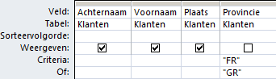

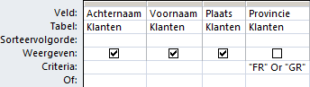

**Oefening 5.2** **Direct mail campagne doos MARS (quer002)**

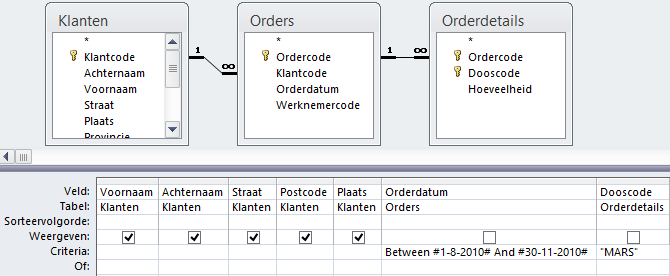

Als conditie voor Orderdatum kun je ook gebruiken `>=#1-8-2010# And <=#30-11-2010#`

**Oefening 5.3** **Bonbondozen met lage prijs (quer003)**

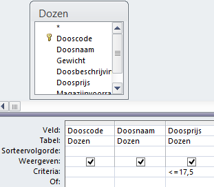

**Oefening 5.4** **Bonbons melk en puur met lage kosten (quer004)**

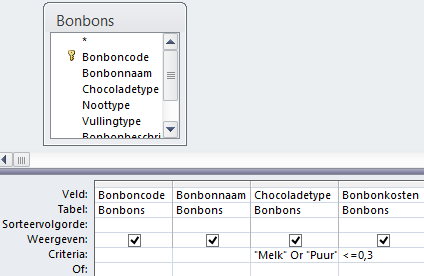

**Oefening 5.5** **Klanten uit Enschede, Hengelo of Almelo (quer005)**

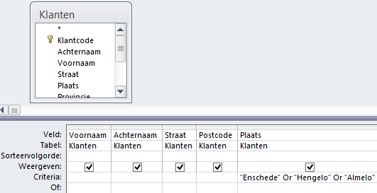

**Oefening 5.6** **Klanten uit Amsterdam met postcode 20 (quer006)**

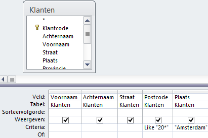

**Oefening 5.7** **Bonbons zonder vulling (quer007)**

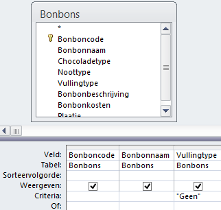

**Oefening 5.8** **Klanten niet uit Amsterdam (quer008)**

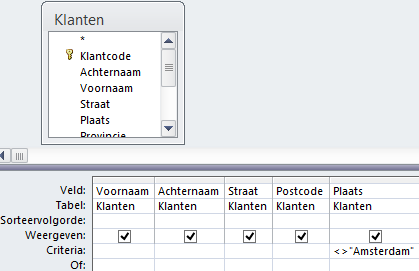

**Oefening 5.9** **Aantal bonbons per doos (quer009)**

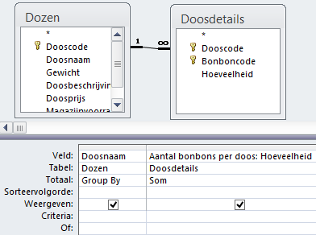

**Oefening 5.10** **Aantal bonbonsoorten per doos (quer010)**

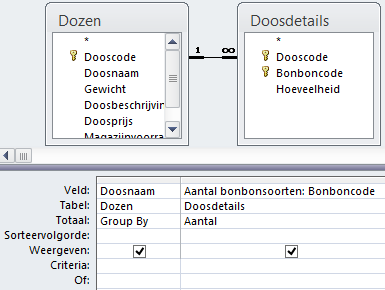

**Oefening 5.11** **Aantal orders per regio (quer011)**

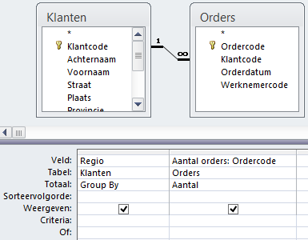

**Oefening 5.12** **Totale omzet per klant (quer012)**

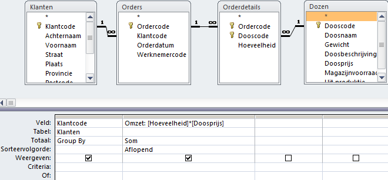

**Oefening 5.13** **Klanten die order geplaatst hebben (quer013)**

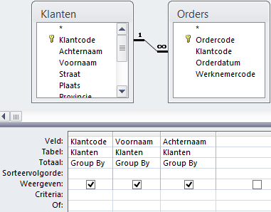

**Oefening 5.14** **Klanten waarvan achternaam Jansen of Janssen is uit regio Noord (quer014)**

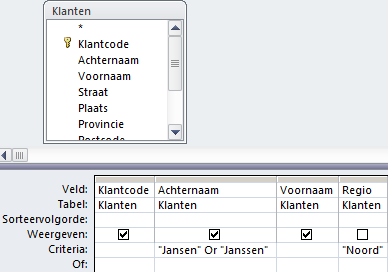

**Oefening 5.15** **Bonbons met vulling en zonder noot (quer015)**

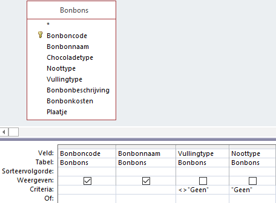

**Oefening 5.16** **Dozen zwaarder dan 150 gram met prijs van hoogstens 35 euro (quer016)**

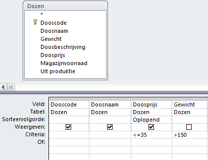

**Oefening 5.17** **Dozen met prijs tussen 17 en 25 en voorraad van minstens 400 (quer017)**

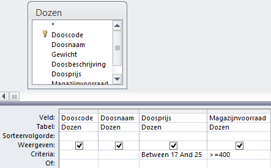

**Oefening 5.18** **Totale omzet per provincie (quer018)**

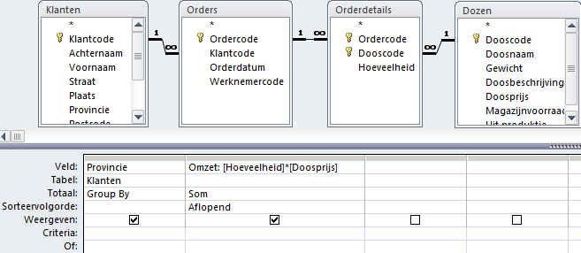

**Oefening 5.19** **Klanten die week voor de kerst besteld hebben (quer019)**

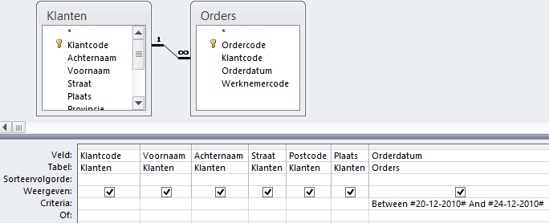

**Oefening 5.20** **Dozen met lage omzet (quer020)**

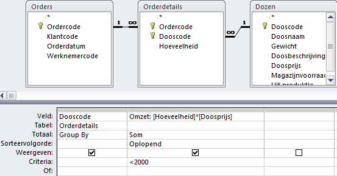

**Oefening 5.21** **Klanten met omzet hoogstens 50 en postcode beginnend met 22 (quer021)**

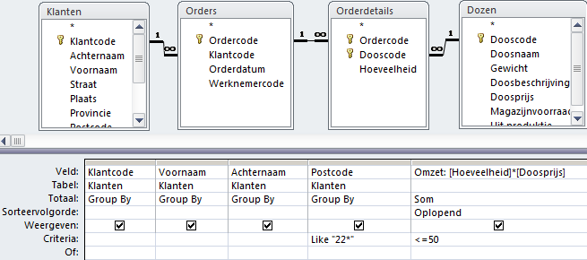

**Oefening 5.22** **Klanten voor Zoet en bitter (quer023)**

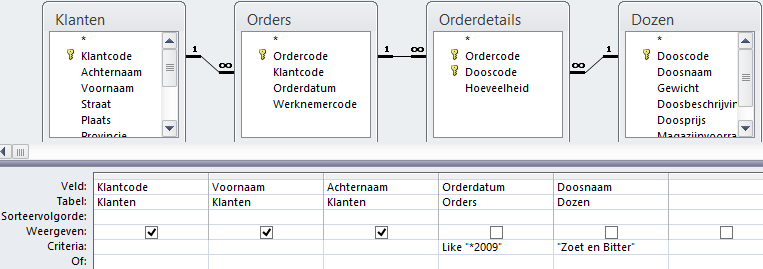

**Oefening 5.23** **Plaatsen met minstens 2 klanten (quer024)**

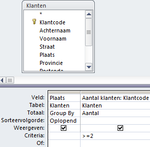

**Oefening 5.24** **Parameterquery bonbons (quer025)**

Maak via Queryontwerp een nieuwe lege query. Voeg de tabel Bonbons aan het queryvenster toe. Voeg de velden Chocoladetype, Bonbonnaam, Bonbonkosten en Bonbonbeschrijving aan het queryraster toe. Voeg in de kolom Chocoladetype bij Criteria in: [Voer chocoladetype in]. Zie de afbeelding hierna.

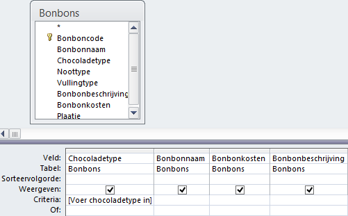

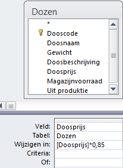

**Oefening 5.25** **Kruistabel dozen per gewicht (quer027)**

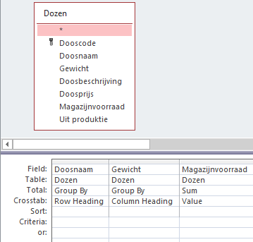

**Oefening 5.26** **Bijwerkquery prijsverhoging (quer028)**

Maak via Queryontwerp een nieuwe query, voeg tabel Dozen toe en dan veld Doosprijs. Wijzig het type query in Bijwerken. Geef het veld Wijzigen in de waarde `[Doosprijs]*1,1`.

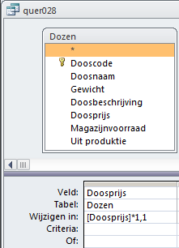

**Oefening 5.27** **Kruistabel omzet per klant per maand (quer029)**

De selectiequery kun je vanuit niets maken, maar je kunt ook het ontwerp van quer012 als basis nemen. Het maandnummer kun je uit het veld Orderdatum halen met de functie `Month()` en het jaar met de functie `Year()`. De waarde `2010` moet bij de laatste als criterium worden toegevoegd.

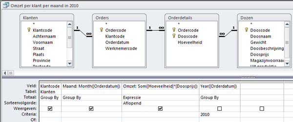

Ontwerp selectiequery

Voor Kies Maken > Wizard Query > Wizard Kruistabelquery. Gebruik de selectiequery als basis. Gebruik veld Klantcode voor de rijkoppen, veld Maand voor de kolomkoppen en `Som(Omzet)` voor de waarden.

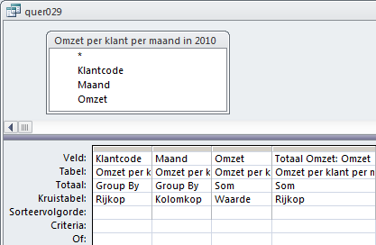

Ontwerp kruistabelquery

# 6 Formulieren

**Oefening 6.1** **Klanten (form001)**

1. Selecteer tabel Klanten.
2. Kies tab Maken > Formulier (groep Formulieren).
3. Zet het formulier in de Ontwerpweergave, verwijder de indeling en breng de wijzigingen in de lay-out aan.

**Oefening 6.2** **Bonbons in dozen (form002)**

1. Kies tab Maken > Wizard formulier.
2. Selecteer tabel Bonbons en voeg alle velden toe.
3. Selecteer tabel Doosdetails en voeg toe de velden Dooscode en Hoeveelheid.
4. Formulier met subformulier, weergeven volgens Bonbons.
5. Zet hoofdformulier in de ontwerpweergave, verwijder de schikking en pas de lay-out aan.

**Oefening 6.3** **Dozen per klant (form003)**

1. Maak eerst als volgt de query Dozen per klant. Kies tab Maken > Queryontwerp. Voeg toe de tabellen Klanten, Orders en Orderdetails. Voeg uit de tabel Klanten de velden Klantcode en Achternaam toe. Voeg uit de tabel Orderdetails de velden Dooscode en Hoeveelheid toe.
2. Kies tab Maken > Wizard formulier.
3. Selecteer tabel Dozen en voeg alle velden toe.
4. Selecteer query Dozen per klant en voeg de velden Klantcode, Achternaam en Hoeveelheid toe.
5. Geef de gegevens weer volgens Dozen in een hoofdformulier met subformulier.

# 7 Rapporten

**Oefening 7.1** **Verkoop per regio per doos (rapp001)**

**Oefening 7.2** **Omzet per doos per regio (rapp002)**

1. Kies tab Maken > Wizard Rapport (groep Rapporten).
2. Kies als gegevensbron de query Verkoop per regio per doos en voeg alle velden toe. Neem als groepeerniveau het veld Doosnaam. Sorteer oplopend op het veld Regio. Kies bij Opties voor totalen voor `Som`, laat weergeven Details en totalen en Percentage van totaal. Kies de indeling Met interval en pas de titel aan.
3. Pas indien nodig in de ontwerpweergave de lay-out van de vakken zodat alles goed wordt weergegeven.

**Oefening 7.3** **Dooskosten met Bonbonkosten (rapp003)**

1. Kies tab Maken > Wizard Rapport (groep Rapporten).
2. Kies als gegevensbron de query Bonbons per doos en voeg alle velden toe. Neem als groepeerniveau het veld Doos. Sorteer oplopend op het veld Bonbon. Kies bij Opties voor totalen voor `Som`, laat weergeven Details en totalen.
3. Wijzig indien nodig in de Ontwerpweergave via het Eigenschappenvenster de notatie van de vakken voor de som in Euro.

**Oefening 7.4** **Dooskosten met Bonbonkosten gegroepeerd (rapp004)**

1. Kopieer en plak rapp003 en noem de kopie rapp004.
2. Open rapport rapp004 in Ontwerpweergave.
3. Klik op een lege plek in de sectie Koptekst en wijzig in Eigenschappenvenster (tab Opmaak) de eigenschap Nieuwe pagina in Voor sectie.
4. Verplaatst de tekst Som naar rechts en plaats een horizontaal lijntje boven de tekst en de waarde.

**Oefening 7.5** **Omzet per doos per order per periode (rapp005)**

1. Kopieer en plak Omzet per doos per order per periode en noem de kopie rapp005.
2. Open rapport rapp005 in Ontwerpweergave.
3. Verplaats het vak Som([Bedrag]) naar de sectie Koptekst, rechts van de Doosnaam.

**Oefening 7.6** **Doos per pagina (rapp006)**

1. Kopieer en plak rapp005 en noem de kopie rapp006.
2. Open rapport rapp006 in Ontwerpweergave.
3. Zet de eigenschap Nieuwe pagina voor de Koptekst (Doosnaam) op de waarde Voor sectie.

**Oefening 7.7** **Doosetiketten (rapp007)**

1. Selecteer tabel Dozen.
2. Kies tab Maken > Etiketten (groep Rapporten).
3. Selecteer de juiste etiketsoort.
4. Stel lettertype, tekengrootte en tekengewicht in.
5. Voeg de velden en tekst toe volgens voorbeeld:

```
{Doosnaam}

Code  : {Dooscode}
Gewicht: {Gewicht} gram
```

6. Sorteer oplopend op Dooscode.

**Oefening 7.8** **Jaarafzet dozen per regio (rapp008)**

Maak een query volgens het ontwerp zoals hierna afgebeeld.

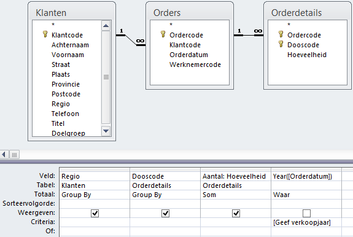

Maak een rapport via tab Maken > Wizard Rapport (groep Rapporten). Baseer het rapport op de query Jaarafzet dozen per regio. Voel alle velden toe en groepeer op Regio. Pas de lay-out verder naar wens aan.

# 8 Integratie

**Oefening 8.1** **intg001 - Standaardbrief (intg001)**

Geef een rechtermuisklik op de naam van de zojuist gemaakte query en kies Exporteren > Word Merge. Kies een nieuw document maken waaraan de gegevens gekoppeld moeten worden.

Voeg de gewenste samenvoegvelden in en typ de overige tekst in, bijvoorbeeld zoals hierna is aangegeven:

```
<<Voornaam>> <<Achternaam>>
<<Straat>>
<<Postcode>>  <<Plaats>>

Beste <<Voornaam>>,
Graag willen we je een aanbieding doen voor onze nieuwste doos ...
```

Handel hierna het samenvoegen verder op de bekende wijze af.

**Oefening 8.2** **intg002 - Export klantgegevens (intg002)**

1. Geef een rechter muisklik op de tabel Klanten en kies Exporteren > Excel.
2. Geef een bestandsnaam en pad op en selecteer de optie Gegevens exporteren met opmaak en indeling.